# 1810055 刘汉青 程序基于R语言

# 6.2(1)用最小距离法建立判别函数

```r
deracea<-data.frame(
  x1=c(189,192,217,221,171,192,213,192,170,201,195,205,180,192,200,192,200,181,192),
  x2=c(245,260,276,299,239,262,278,255,244,276,242,263,252,283,294,277,287,255,287),
  x3=c(137,132,141,142,128,147,136,128,128,146,128,147,121,138,138,159,136,146,141),
  x4=c(163,217,192,213,158,173,201,185,129,186,192,192,167,183,188,177,173,183,198)
)
carduorum<-data.frame(
  x1=c(181,158,184,171,181,181,177,198,180,177,176,192,176,169,164,181,192,181,175,197),
  x2=c(305,237,300,273,297,297,301,308,286,299,317,312,285,287,265,308,276,278,271,303),
  x3=c(184,133,166,162,160,163,166,142,146,171,166,166,141,162,147,157,154,149,140,170),
  x4=c(209,231,231,213,223,224,221,197,214,192,213,209,200,214,192,204,209,235,192,205)
)
```

- 假设两总体协方差相同

```r
S <- var(rbind(deracea,carduorum))
mu1 <- colMeans(deracea); mu2 <- colMeans(carduorum)
TstX<-rbind(deracea,carduorum)
W <- mahalanobis(TstX, mu2, S) - mahalanobis(TstX, mu1, S)
```

若$w>0$,判断属于deracea总体，若$w<0$,判断属于carduorum总体

- 假设两总体协方差不同

```r
S1 <- var(deracea); S2 <- var(carduorum)
W <- mahalanobis(TstX, mu2, S2) - mahalanobis(TstX, mu1, S1)
```

若$w>0$,判断属于deracea总体，若$w<0$,判断属于carduorum总体

# 6.2(2)建立bayes判别区域

```r
lossrate<-1
rate<-(2/3)/(1/3)
```

- 假设两总体协方差不同

```r
beta <- log(1/rate) +log(lossrate)+ 0.5*log(det(S1)/det(S2))
beta
W <- 0.5*(mahalanobis(TstX,mu2,S2) - mahalanobis(TstX,mu1,S1))
```

-0.56043376533662

若$w\geqslant \beta$,判断属于deracea总体，若$w< \beta$,判断属于candorum总体

- 假设两总体协方差相同

```r
beta <- log(1/rate)+log(lossrate)
beta
W <- 0.5*(mahalanobis(TstX,mu2,S) - mahalanobis(TstX,mu1,S))
```

-0.693147180559945

若$w\geqslant \beta$,判断属于deracea总体，若$w< \beta$,判断属于candorum总体

# 6.2(3)误判率比较

- 最小距离判别

```r
discriminant.distance <- function(Train1,Train2,TstX=NULL,var.equal=FALSE){
  TstX<-rbind(Train1,Train2)
  nx <- nrow(TstX)    # 测试集的大小
  # 生成长度为nx的0向量，用以存储预测的标签
  blong <- matrix(rep(0,nx),nrow=1,byrow=TRUE,dimnames=list("blong",1:nx))
  mu1 <- colMeans(Train1); mu2 <- colMeans(Train2)
  # 两群体同方差
  if (var.equal == TRUE || var.equal == T){
    # 计算混合样本方差
    S <- var(rbind(Train1,Train2))
    W <- mahalanobis(TstX, mu2, S) - mahalanobis(TstX, mu1, S)
  }
  # 两群体异方差
  else{
    S1 <- var(Train1); S2 <- var(Train2)
    W <- mahalanobis(TstX, mu2, S2) - mahalanobis(TstX, mu1, S1)
  }
  for (i in 1:nx){
    if (W[i] > 0)
      blong[i] <- 1
    else
      blong[i] <- 2
  }
  blong
}
```

- bayes判别

```r
discriminant.bayes <- function(TrnX1,TrnX2,rate=1,lossrate=1,TstX=NULL,var.equal=FALSE){
  TstX<-rbind(TrnX1,TrnX2)
  nx<-nrow(TstX)
  blong <- matrix(rep(0,nx), nrow=1, byrow=TRUE, dimnames = list("blong",1:nx))
  mu1 <- colMeans(TrnX1); mu2 <- colMeans(TrnX2)
  if (var.equal == TRUE || var.equal == T){
    S <- var(rbind(TrnX1,TrnX2))
    beta <- log(1/rate)+log(lossrate)
    W <- 0.5*(mahalanobis(TstX,mu2,S) - mahalanobis(TstX,mu1,S))
  }else{
    S1 <- var(TrnX1); S2 <- var(TrnX2)
    beta <- log(1/rate) +log(lossrate)+ 0.5*log(det(S1)/det(S2))
    W <- 0.5*(mahalanobis(TstX, mu2, S2) - mahalanobis(TstX, mu1, S1))
  }

  for (i in 1:nx){
    if (W[i] > beta)
      blong[i] <- 1
    else
      blong[i] <- 2
  }
  blong
}
```

- 最小距离&总体协方差相等

```r
print(discriminant.distance(carduorum,deracea,var.equal = TRUE))
```

```
      1 2 3 4 5 6 7 8 9 10 11 12 13 14 15 16 17 18 19 20 21 22 23 24 25 26 27
blong 1 1 1 1 1 1 1 2 1  1  1  1  1  1  1  1  1  1  1  1  2  2  2  2  2  2  2
      28 29 30 31 32 33 34 35 36 37 38 39
blong  2  2  2  2  2  2  2  2  2  2  2  2
```

- 最小距离&总体协方差不相等

```r
print(discriminant.distance(carduorum,deracea))
```

```
      1 2 3 4 5 6 7 8 9 10 11 12 13 14 15 16 17 18 19 20 21 22 23 24 25 26 27
blong 1 1 1 1 1 1 1 1 1  1  1  1  1  1  1  1  1  1  1  1  2  2  2  2  2  2  2
      28 29 30 31 32 33 34 35 36 37 38 39
blong  2  2  2  2  2  2  2  2  2  2  2  2
```

- bayes&总体协方差相等

```r
print(discriminant.bayes(deracea,carduorum,rate=2,lossrate=1,var.equal = TRUE))
```

```
      1 2 3 4 5 6 7 8 9 10 11 12 13 14 15 16 17 18 19 20 21 22 23 24 25 26 27
blong 1 1 1 1 1 1 1 1 1  1  1  1  1  1  1  1  1  1  1  2  2  2  2  2  2  2  1
      28 29 30 31 32 33 34 35 36 37 38 39
blong  2  2  2  2  2  2  2  2  1  2  1  1
```

- bayes&总体协方差不相等

```r
print(discriminant.bayes(deracea,carduorum,rate=2,lossrate=1))
```

```
      1 2 3 4 5 6 7 8 9 10 11 12 13 14 15 16 17 18 19 20 21 22 23 24 25 26 27
blong 1 1 1 1 1 1 1 1 1  1  1  1  1  1  1  1  1  1  1  2  2  2  2  2  2  2  1
      28 29 30 31 32 33 34 35 36 37 38 39
blong  2  2  2  2  2  2  2  2  2  2  2  2
```

# 7.10主成分分析

```r
d<-read.csv('D:/讲义笔记/7题.csv')
```

## 用样本相关系数矩阵做主成分分析

```r
pcacor<-princomp(d,cor=TRUE)
summary(pcacor,loading=TRUE)
```

```
Importance of components:
                         Comp.1    Comp.2    Comp.3    Comp.4     Comp.5
Standard deviation     1.532087 1.1691537 1.0990627 0.8536564 0.80899771
Proportion of Variance 0.335327 0.1952743 0.1725627 0.1041042 0.09349676
Cumulative Proportion  0.335327 0.5306014 0.7031641 0.8072682 0.90076499
                           Comp.6     Comp.7
Standard deviation     0.73431600 0.39423991
Proportion of Variance 0.07703143 0.02220359
Cumulative Proportion  0.97779641 1.00000000

Loadings:
    Comp.1 Comp.2 Comp.3 Comp.4 Comp.5 Comp.6 Comp.7
x_1  0.232  0.260  0.654  0.152  0.574  0.209  0.233
x_2 -0.204 -0.540  0.199  0.783 -0.119
x_3 -0.550        -0.117         0.571        -0.590
x_4 -0.375  0.447 -0.397  0.288         0.456  0.458
x_5 -0.497  0.196  0.196               -0.749  0.337
x_6 -0.333 -0.560  0.155 -0.519         0.324  0.417
x_7 -0.321  0.298  0.547 -0.105 -0.570  0.270 -0.317
```

- 在上表所示结果中，importance of components表格表示不同主成分的重要程度，其中standard deviation表示每个主成分的标准差，proportion of variance表示每个主成分的方差贡献率，cumulative proportion表示到该主成分时的方差累计贡献率。
- loadings表示每个主成分对载荷的线性组合中，载荷的系数
- 可以看出，通过样本相关系数矩阵的主成分分析中，获得的七个主成分在第五个主成分处对超过90%的方差进行了解释，可以选择前五个主成分，每个主成分由loadings中的系数矩阵决定
- 以第一个主成分为例$COMP1=0.232*风速+(-0.204)*阳光强度+(-0.550)CO*+(-0.375)*NO+(-0.497)*NO^2+(-0.333)*O^3+(-0.321)*HC$

## 用样本协方差矩阵做主成分分析

```r
pcacov<-princomp(d,cor=FALSE)
summary(pcacov,loading=TRUE)
```

```
Importance of components:
                           Comp.1    Comp.2    Comp.3      Comp.4      Comp.5
Standard deviation     17.2303441 5.2577376 3.3336394 1.573759428 1.117473897
Proportion of Variance  0.8729649 0.0812843 0.0326773 0.007282585 0.003671839
Cumulative Proportion   0.8729649 0.9542492 0.9869265 0.994209042 0.997880881
                            Comp.6       Comp.7
Standard deviation     0.719429212 0.4506753206
Proportion of Variance 0.001521896 0.0005972228
Cumulative Proportion  0.999402777 1.0000000000

Loadings:
    Comp.1 Comp.2 Comp.3 Comp.4 Comp.5 Comp.6 Comp.7
x_1                       0.923  0.340         0.165
x_2 -0.993  0.114
x_3        -0.103 -0.179 -0.139  0.645 -0.568 -0.446
x_4               -0.131 -0.322  0.650  0.495  0.459
x_5        -0.162 -0.954  0.102 -0.205         0.105
x_6 -0.110 -0.972  0.182
x_7                       0.110         0.655 -0.740
```

- 对表格形式内容的解释同上。
- 方差贡献率显示，前两个主成分的累计方差贡献率已经超过95%，因此选择前两个主成分
- 以第一个主成分为例$COMP1=(-0.993)*阳光强度+(-0.110)*O^3$

# 8.3因子分析

```r
install.packages('psych')
library('psych')
dd<-as.matrix(read.csv('D:/讲义笔记/8.csv',head=F))
```

## 尝试三因子

```r
pc3<-principal(dd,nfactors=3,rotate='varimax')
pc3
```

```
Principal Components Analysis
Call: principal(r = dd, nfactors = 3, rotate = "varimax")
Standardized loadings (pattern matrix) based upon correlation matrix
      RC1   RC2   RC3   h2   u2 com
V1  -0.07  0.14  0.64 0.44 0.56 1.1
V2  -0.12  0.48  0.26 0.32 0.68 1.7
V3  -0.62  0.13  0.02 0.40 0.60 1.1
V4  -0.05  0.52  0.07 0.28 0.72 1.1
V5   0.04  0.75 -0.15 0.58 0.42 1.1
V6   0.28  0.77 -0.07 0.68 0.32 1.3
V7   0.03  0.56 -0.62 0.70 0.30 2.0
V8   0.49  0.68  0.01 0.70 0.30 1.8
V9  -0.14  0.09  0.78 0.64 0.36 1.1
V10  0.65  0.43  0.16 0.63 0.37 1.9
V11  0.73  0.07  0.15 0.56 0.44 1.1
V12  0.77  0.24 -0.10 0.66 0.34 1.2
V13  0.70  0.03 -0.21 0.53 0.47 1.2
V14  0.59 -0.11 -0.26 0.42 0.58 1.4
V15  0.14 -0.49  0.61 0.64 0.36 2.0

                       RC1  RC2  RC3
SS loadings           3.14 2.98 2.05
Proportion Var        0.21 0.20 0.14
Cumulative Var        0.21 0.41 0.54
Proportion Explained  0.38 0.36 0.25
Cumulative Proportion 0.38 0.75 1.00

Mean item complexity =  1.4
Test of the hypothesis that 3 components are sufficient.

The root mean square of the residuals (RMSR) is  0.11
 with the empirical chi square  39.57  with prob <  0.99

Fit based upon off diagonal values = 0.83
```

## 尝试四因子

```r
pc4<-principal(dd,nfactors=4,rotate='varimax')
pc4
```

```
Principal Components Analysis
Call: principal(r = dd, nfactors = 4, rotate = "varimax")
Standardized loadings (pattern matrix) based upon correlation matrix
      RC1   RC2   RC3   RC4   h2   u2 com
V1  -0.11  0.22  0.68  0.10 0.53 0.47 1.3
V2  -0.03  0.51  0.27 -0.09 0.34 0.66 1.6
V3  -0.19 -0.03 -0.09 -0.90 0.85 0.15 1.1
V4  -0.14  0.65  0.14  0.26 0.53 0.47 1.5
V5   0.15  0.74 -0.14 -0.02 0.60 0.40 1.2
V6   0.43  0.70 -0.09 -0.04 0.68 0.32 1.7
V7   0.01  0.60 -0.60  0.13 0.74 0.26 2.1
V8   0.66  0.54 -0.04 -0.04 0.73 0.27 1.9
V9   0.02  0.05  0.75 -0.28 0.65 0.35 1.3
V10  0.78  0.26  0.10  0.03 0.68 0.32 1.3
V11  0.76 -0.08  0.10  0.14 0.62 0.38 1.1
V12  0.84  0.06 -0.16  0.11 0.74 0.26 1.1
V13  0.67 -0.10 -0.24  0.22 0.57 0.43 1.5
V14  0.17  0.05 -0.16  0.86 0.80 0.20 1.2
V15 -0.04 -0.43  0.65  0.27 0.68 0.32 2.1

                       RC1  RC2  RC3  RC4
SS loadings           3.07 2.71 2.06 1.89
Proportion Var        0.20 0.18 0.14 0.13
Cumulative Var        0.20 0.39 0.52 0.65
Proportion Explained  0.32 0.28 0.21 0.19
Cumulative Proportion 0.32 0.59 0.81 1.00

Mean item complexity =  1.5
Test of the hypothesis that 4 components are sufficient.

The root mean square of the residuals (RMSR) is  0.08
 with the empirical chi square  22.41  with prob <  1

Fit based upon off diagonal values = 0.91
```

## 尝试五因子

```r
pc5<-principal(dd,nfactors=5,rotate='varimax')
pc5
```

```
Principal Components Analysis
Call: principal(r = dd, nfactors = 5, rotate = "varimax")
Standardized loadings (pattern matrix) based upon correlation matrix
      RC2   RC1   RC3   RC4   RC5   h2   u2 com
V1   0.05 -0.12  0.59  0.08  0.40 0.54 0.46 1.9
V2   0.08  0.08  0.07 -0.17  0.74 0.59 0.41 1.2
V3  -0.09 -0.14 -0.11 -0.92  0.02 0.88 0.12 1.1
V4   0.18 -0.07 -0.08  0.19  0.78 0.69 0.31 1.3
V5   0.80 -0.12 -0.17  0.04  0.17 0.71 0.29 1.2
V6   0.84  0.16 -0.10  0.03  0.14 0.77 0.23 1.2
V7   0.41 -0.03 -0.69  0.13  0.29 0.75 0.25 2.1
V8   0.78  0.42 -0.02  0.02  0.05 0.78 0.22 1.6
V9   0.09 -0.05  0.74 -0.27  0.14 0.65 0.35 1.4
V10  0.57  0.59  0.16  0.08 -0.06 0.71 0.29 2.2
V11 -0.05  0.88  0.07  0.07  0.17 0.82 0.18 1.1
V12  0.28  0.81 -0.13  0.10 -0.05 0.76 0.24 1.3
V13  0.08  0.70 -0.20  0.20 -0.11 0.60 0.40 1.4
V14  0.02  0.19 -0.16  0.86  0.05 0.80 0.20 1.2
V15 -0.26 -0.05  0.73  0.30 -0.21 0.73 0.27 1.8

                       RC2  RC1  RC3  RC4  RC5
SS loadings           2.66 2.59 2.08 1.89 1.58
Proportion Var        0.18 0.17 0.14 0.13 0.11
Cumulative Var        0.18 0.35 0.49 0.61 0.72
Proportion Explained  0.25 0.24 0.19 0.18 0.15
Cumulative Proportion 0.25 0.49 0.68 0.85 1.00

Mean item complexity =  1.5
Test of the hypothesis that 5 components are sufficient.

The root mean square of the residuals (RMSR) is  0.07
 with the empirical chi square  17.11  with prob <  1

Fit based upon off diagonal values = 0.93
```

# 10.7聚类

- 用kmeans执行聚类，结果如图所示

```
K-means clustering with 3 clusters of sizes 15, 10, 5

Cluster means:
        V1   V2   V3       V4
1 5.906667 2.72 4.42 1.453333
2 4.860000 3.31 1.45 0.220000
3 6.980000 3.06 5.94 2.060000

Clustering vector:
 [1] 2 2 2 2 2 2 2 2 2 2 1 1 1 1 1 1 1 1 1 1 1 3 1 3 1 3 3 1 1 3

Within cluster sum of squares by cluster:
[1] 11.27467  1.77400  2.16400
 (between_SS / total_SS =  88.4 %)

Available components:

[1] "cluster"      "centers"      "totss"        "withinss"     "tot.withinss"
[6] "betweenss"    "size"         "iter"         "ifault"
```

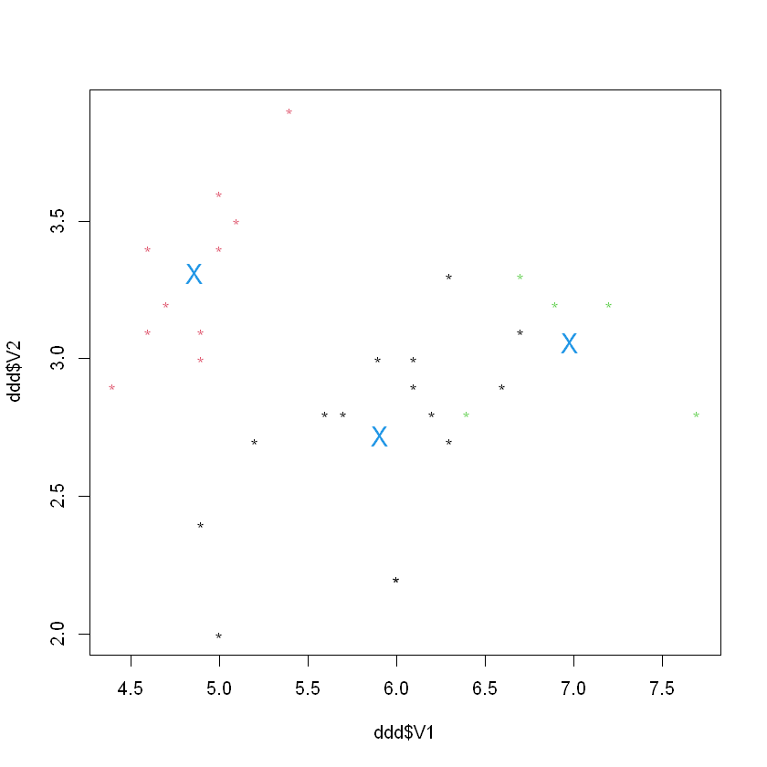

```r
ddd<-read.csv('D:/讲义笔记/10题.csv',head=F)
ddd.kmeans<-kmeans(ddd,3)
ddd.kmeans
plot(ddd$V1,ddd$V2,col=ddd.kmeans$cluster,pch="*")
points(ddd.kmeans$centers,pch="X",cex=1.5,col=4)
```